# Football Analytics

[figure not shown]

##### Disclaimer: the developer of this notebook is not a Real Madrid fan.

# Load libraries

```r
library(RSQLite)
library(tidyverse)
library(purrr)
library(skimr)
library(scales)
library(data.table)
library(caret)
library(caretEnsemble)
```

# Load data

```r
# connect to sqlite database
con <- dbConnect(drv=RSQLite::SQLite(), dbname="./data/database.sqlite")

# list tables
tables <- dbListTables(con)

# select appropriate tables
tables <- tables[tables != "sqlite_sequence"]

# create empty list with lenght of table amount
data_all <- vector("list", length=length(tables))

# load tables into list as dataframes
for (i in seq(along=tables)) {
  data_all[[i]] <- dbGetQuery(conn=con, statement=paste("SELECT * FROM '", tables[[i]], "'", sep=""))
}

rm(i, con, tables)
```

# Exploring, organising and cleaning data

```r
# first peek at dataframes
map(data_all, tail)
```

```
## [[1]]
##       id        name
## 6  13274 Netherlands
## 7  15722      Poland
## 8  17642    Portugal
## 9  19694    Scotland
## 10 21518       Spain
## 11 24558 Switzerland
##
## [[2]]
##       id country_id                     name
## 6  13274      13274   Netherlands Eredivisie
## 7  15722      15722       Poland Ekstraklasa
## 8  17642      17642 Portugal Liga ZON Sagres
## 9  19694      19694  Scotland Premier League
```

[output cut: 320 more lines]

```r
# explore data distributions without histograms
map(data_all, skim)
```

```
## [[1]]
## Skim summary statistics
##  n obs: 11
##  n variables: 2
##
## Variable type: character
##  variable missing complete  n min max empty n_unique
##      name       0       11 11   5  11     0       11
##
## Variable type: integer
##  variable missing complete  n     mean      sd p0  p25 median   p75  p100
##        id       0       11 11 12452.09 8215.31  1 6289  13274 18668 24558
##      hist
##  ▇▃▃▃▃▇▃▇
##
## [[2]]
## Skim summary statistics
##  n obs: 11
##  n variables: 3
##
## Variable type: character
##  variable missing complete  n min max empty n_unique
##      name       0       11 11  13  24     0       11
##
## Variable type: integer
##    variable missing complete  n     mean      sd p0  p25 median   p75
##  country_id       0       11 11 12452.09 8215.31  1 6289  13274 18668
##          id       0       11 11 12452.09 8215.31  1 6289  13274 18668
##   p100     hist
##  24558 ▇▃▃▃▃▇▃▇
##  24558 ▇▃▃▃▃▇▃▇
##
## [[3]]
## Skim summary statistics
##  n obs: 25979
##  n variables: 115
##
## Variable type: character
##    variable missing complete     n min   max empty n_unique
##        card   11762    14217 25979   8  4849     0    13777
```

[output cut: 415 more lines]

```
##             team_api_id       0     1458 1458  9995.73 13264.87 1601
##        team_fifa_api_id       0     1458 1458 17706.98 39179.86    1
##      p25 median     p75   p100     hist
##    42      49     55        77 ▁▃▃▇▇▂▂▁
##    40      50     55        80 ▁▃▅▇▇▃▂▁
##    45      52     62        80 ▁▃▃▇▆▇▅▁
##    47      53     62        80 ▁▂▃▇▇▆▅▁
##    46      52     59        80 ▁▂▃▇▇▃▃▁
##    48      53     61        80 ▁▂▂▇▇▅▃▁
##    44      48     55        72 ▁▁▃▇▅▅▁▂
##    39      45     51        72 ▁▃▅▇▅▃▂▁
##    47      52     58        73 ▂▂▂▇▇▃▃▂
##   365.25  729.5 1093.75   1458 ▇▇▇▇▇▇▇▇
##  8457.75 8674   9904    274581 ▇▁▁▁▁▁▁▁
##   110     485   1900    112513 ▇▁▁▁▁▁▁▂
```

Lots of tables, lots of data, lots of interesting observations to be made! We’ll start with a few things that stand out first and might get into more detailed analysis later as we prepare for advanced analytics on specific metriccs.

## What stands out?

### Games

Let’s make sure our complete group is indeed a consistent homogeneous set, and the missing values are not scattered around. We’ll omit the Maybe starting player positions columns. These variables seem very prone to missing entries as noted in the dataset documentation:

> You will notice that some players are missing from the lineup (NULL values). This is because I have not been able to source their attributes from FIFA. This will be fixed overtime as the crawling algorithm is being improved. The dataset will also be expanded to include international games, national cups, Champion’s League and Europa League. Please ask me if you’re after a specific tournament.

```r
data_all[[3]] %>%
  select(-grep("*player*", as.character(names(data_all[[3]])))) %>%
  complete.cases() %>%
  sum()
```

```
## [1] 1803
```

Okay, that number is way too low as opposed to what we expected. It could be that non-occurances of events are entered as NA’s here. For example if a match is player, but no cards were given. Let’s take note that the games table needs further inspection if we are to use it in our analysis later on.

### Attributes

Again, quite a few incomplete records. This time there seem to be two consistent groups of incomplete data (836 and 2713) and a consistent group of complete records with a count of 181,265. Let’s make sure this is the case:

```r
data_all[[5]] %>%
  complete.cases() %>%
  sum()
```

```
## [1] 180354
```

This number is fairly consistent in what we observed in our skim of the data, excellent!

### Tactics

In this table we have a few missing values (969) for the variable ‘buildUpPlayDribbling’.

### Other tables

All other tables look good at first glance.

# KPN Consulting assignment 1: Final Season Tables

### Adding wins, draws and losses

First off, we use some simple logic to add columns representing wins, draws, losses and the corresponding points total for the home and away teams.

```r
#generate points from matches
data_all[[3]] <- data_all[[3]] %>%
  mutate(home_team_points = case_when(
                                  home_team_goal > away_team_goal ~ 3,
                                  home_team_goal == away_team_goal ~ 1,
                                  home_team_goal < away_team_goal ~ 0
                                ),
        away_team_points = case_when(
                                  home_team_goal < away_team_goal ~ 3,
                                  home_team_goal == away_team_goal ~ 1,
                                  home_team_goal > away_team_goal ~ 0
                                ),
        home_result = case_when(
                                  home_team_goal > away_team_goal ~ "W",
                                  home_team_goal == away_team_goal ~ "D",
                                  home_team_goal < away_team_goal ~ "L"
                                ),
        away_result = case_when(
                                  home_team_goal < away_team_goal ~ "W",
                                  home_team_goal == away_team_goal ~ "D",
                                  home_team_goal > away_team_goal ~ "L"
                                )
)

# sanity check
data_all[[3]] %>%
  select(home_team_goal, away_team_goal, home_team_points, away_team_points, home_result, away_result) %>%
  tail(20)
```

```
##       home_team_goal away_team_goal home_team_points away_team_points
## 25960              1              3                0                3
## 25961              1              3                0                3
## 25962              0              2                0                3
## 25963              1              0                3                0
## 25964              2              5                0                3
## 25965              0              1                0                3
## 25966              1              0                3                0
## 25967              0              2                0                3
## 25968              3              1                3                0
## 25969              3              2                3                0
## 25970              2              1                3                0
## 25971              4              0                3                0
## 25972              3              3                1                1
## 25973              3              3                1                1
```

[output cut: 27 more lines]

Now that the logic works, we’ll pivot the data to create a flat file containing everything we need. We’ve kept the split between home and away games to be be able to slice on that in PowerBI.

```r
# create league flat table with all league tables
league_tables <- rbind(
  data_all[[3]] %>%
    spread(home_result, home_result) %>%
    group_by(league_id, season, home_team_api_id) %>%
    summarise("home_or_away" = "home",
              "Pts" = sum(home_team_points),
              "GF" = sum(home_team_goal),
              "GA" = sum(away_team_goal),
              "W" = sum(!is.na(W)),
              "D" = sum(!is.na(D)),
              "L" = sum(!is.na(L)),
              "Pld" = n()) %>%
    mutate(team_api = home_team_api_id, GD = GF - GA) %>%
    select(-home_team_api_id),
  data_all[[3]] %>%
    spread(away_result, away_result) %>%
    group_by(league_id, season, away_team_api_id) %>%
    summarise("home_or_away" = "away",
              "Pts" = sum(away_team_points),
              "GF" = sum(away_team_goal),
              "GA" = sum(home_team_goal),
              "W" = sum(!is.na(W)),
              "D" = sum(!is.na(D)),
              "L" = sum(!is.na(L)),
              "Pld" = n()) %>%
    mutate(team_api = away_team_api_id, GD = GF - GA) %>%
    select(-away_team_api_id)
) %>%
  left_join(data_all[[2]], by = c("league_id" = "id")) %>% #add League names
  left_join(data_all[[6]], by = c("team_api" = "team_api_id")) #add team names

# check the result
league_tables %>%
  filter(season == "2014/2015", name == "Netherlands Eredivisie") %>%
  select(team_long_name, Pld, W, D, L, GF, GA, GD, Pts) %>%
  arrange(desc(Pts))
```

```
## # A tibble: 36 x 11
## # Groups: league_id, season [1]
##    league_id season    team_long_name   Pld     W     D     L    GF    GA
##        <int> <chr>     <chr>          <int> <int> <int> <int> <int> <int>
##  1     13274 2014/2015 PSV               17    16     0     1    50    12
##  2     13274 2014/2015 PSV               17    13     1     3    42    19
##  3     13274 2014/2015 Ajax              17    12     3     2    37    11
##  4     13274 2014/2015 PEC Zwolle        17    11     4     2    40    15
##  5     13274 2014/2015 Vitesse           17     8     8     1    36    18
##  6     13274 2014/2015 Feyenoord         17    10     2     5    31    20
##  7     13274 2014/2015 Ajax              17     9     5     3    32    18
##  8     13274 2014/2015 AZ                17    10     2     5    33    29
##  9     13274 2014/2015 AZ                17     9     3     5    30    27
## 10     13274 2014/2015 Willem II         17     8     5     4    25    22
## # ... with 26 more rows, and 2 more variables: GD <int>, Pts <dbl>
```

The gives us a binded table of all league results from seasons. Using the season and league columns we can now easily make our selections in PowerBI. Note that in PowerBI the home and away values will which are split in this flat table will be aggregated to create a league table with 1 row per team.

# KPN Consulting assignment 2: Head-to-head overview

This assignment is completed using solely PowerBI. Please see the PBIX dashboard file for results.

# Extra Feature 1: The Hand of God

As modern football progresses, set pieces such as corners and free kicks have become more advanced as well. Traditionally the tallest players are marked heaviest on long passes, corners and crosses, as they are supposedly most prone to score with their heads. But who are most dangerous high flyers amongst the smaller players? To find out, we will scale both height and heading accuracy and then look at relative accurary points scored relative to smallness (as opposed to tallness).

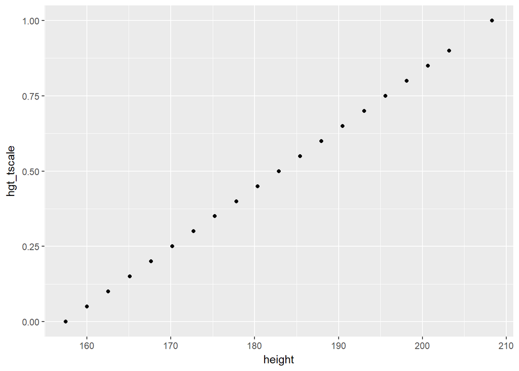

```r
# create difference ranges of height in CM and heading accuracy
range_hac <- max(data_all[[5]]$heading_accuracy, na.rm = TRUE)-min(data_all[[5]]$heading_accuracy, na.rm = TRUE)
range_hgt <- max(data_all[[4]]$height, na.rm = TRUE)-min(data_all[[4]]$height, na.rm = TRUE)

# create relative scales (1-100) for both height and heading accuracy and add them to oin
temp_df <- data_all[[5]] %>%
  left_join(data_all[[4]], by = "player_api_id") %>%
  mutate(
    hac_scale = ((heading_accuracy - min(heading_accuracy, na.rm = TRUE)))/range_hac,
    hgt_tscale = ((height - min(height, na.rm = TRUE)))/range_hgt
  )

# sanity check on scaled values, should be linear (slope = 1, intercept = 0)
ggplot(temp_df, aes(x = height, y = hgt_tscale)) + geom_point()
```

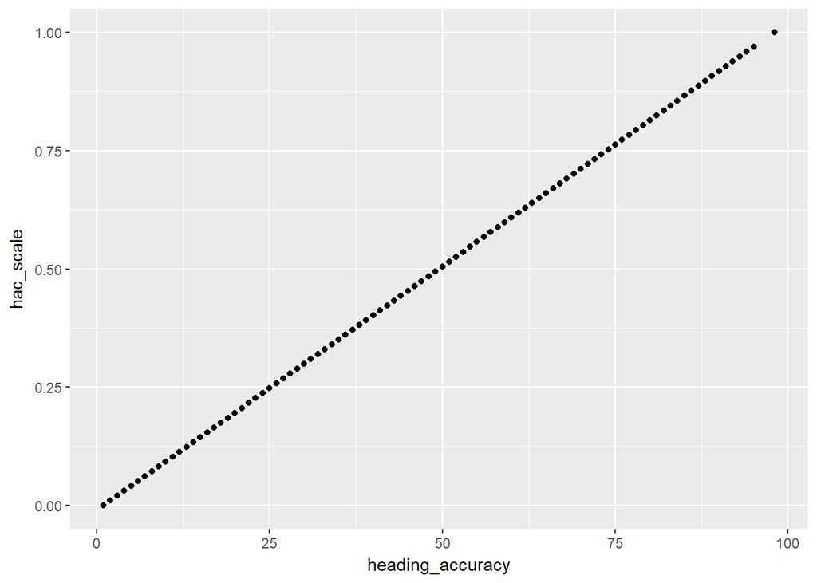

```r
ggplot(temp_df, aes(x = heading_accuracy, y = hac_scale)) + geom_point()
```

The scaled features look right. Now we can easily add the Hand of God Rating. We will calculate this for the full player attribute set from all seasons and then take the average per player. Also, we’ll only look at players with a heading accuracy of over 70 as are looking to find small players with a decent succes rate in heading.

```r
# adding Hand of God Rating
temp_df %>%
  filter(heading_accuracy > 70) %>%
  mutate(HoGR = round(rescale((hac_scale / hgt_tscale), to = c(1, 99)))) %>%
  arrange(desc(HoGR)) %>%
  select(player_name, height, overall_rating, heading_accuracy, HoGR) %>%
  group_by(player_name) %>%
  summarise("avg height" = round(mean(height)),
            "avg overall rating" = round(mean(overall_rating)),
            "avg heading_accuracy" = round(mean(heading_accuracy)),
            "HoGR" = round(mean(HoGR))
            ) %>%
  arrange(desc(HoGR)) %>%
  head(20)
```

```
## # A tibble: 20 x 5
##    player_name       `avg height` `avg overall rat~ `avg heading_ac~  HoGR
##    <chr>                    <dbl>             <dbl>            <dbl> <dbl>
##  1 Pablo Piatti               163              77.0             74.0  94.0
##  2 Wilfried Sanou             165              64.0             81.0  66.0
##  3 Matias Alustiza            165              74.0             72.0  58.0
##  4 Franco Brienza             168              77.0             79.0  46.0
##  5 Koikili Campo              168              67.0             74.0  42.0
##  6 Alessandro Rosina          168              79.0             72.0  41.0
##  7 Javier Saviola             168              80.0             71.0  40.0
##  8 Alexis Sanchez             170              73.0             79.0  35.0
##  9 Kevin Phillips             170              75.0             80.0  35.0
## 10 Julian de Guzman           170              77.0             78.0  34.0
## 11 Oscar Ewolo                170              69.0             76.0  33.0
## 12 Alhassane Keita            170              75.0             75.0  32.0
## 13 Andrew Johnson             170              80.0             75.0  32.0
## 14 Cristian Benitez           170              76.0             74.0  32.0
## 15 Eder Luis                  170              74.0             75.0  32.0
## 16 Leighton Baines            170              81.0             73.0  32.0
## 17 Makelele                   170              68.0             74.0  32.0
## 18 Paul Scholes               170              82.0             75.0  32.0
## 19 Vicente Sanchez            170              76.0             75.0  32.0
## 20 Wissam Ben Yedder          170              76.0             75.0  32.0
```

```r
# clean up environment
rm(range_hac, range_hgt)
```

And here we have our group of 20 elite small headers. One Pablo Piatti absolutely dominating on this score with a Hand of God Rating of 94. Some well known elite players in this top 20 as well, such as Javier Saviola, Paul Scholes and Leighton Baines. Less stars like Sanou and Campo make it high on this list as well. Old man Makelele, here on the back-end of his career, also still proves he can rise up amongst the trees to knock it home.

### Business application

The HoGR can be applied in scouting reports to know who to pay extra attention to during set pieces, despite their height.

# Extra Feature 2: Types of Players

We will use the basic k-means algorithm to seperate players into homogeneous groups based on their attributes.

### Select columns for clustering

```r
# look at the original data
head(temp_df)
```

```
##   id.x player_fifa_api_id.x player_api_id                date
## 1    1               218353        505942 2016-02-18 00:00:00
## 2    2               218353        505942 2015-11-19 00:00:00
## 3    3               218353        505942 2015-09-21 00:00:00
## 4    4               218353        505942 2015-03-20 00:00:00
## 5    5               218353        505942 2007-02-22 00:00:00
## 6    6               189615        155782 2016-04-21 00:00:00
##   overall_rating potential preferred_foot attacking_work_rate
## 1             67        71          right              medium
## 2             67        71          right              medium
## 3             62        66          right              medium
## 4             61        65          right              medium
## 5             61        65          right              medium
## 6             74        76           left                high
##   defensive_work_rate crossing finishing heading_accuracy short_passing
```

[output cut: 55 more lines]

```r
# make a selection and scale the data
data_cluster <- temp_df %>%
  select(overall_rating, potential, crossing, finishing, heading_accuracy, short_passing, volleys, dribbling, curve, free_kick_accuracy, long_passing, ball_control, acceleration, sprint_speed, agility, reactions, balance, shot_power, jumping, stamina, strength, long_shots, aggression, interceptions, positioning, vision, penalties, marking, standing_tackle, sliding_tackle, gk_diving, gk_handling, gk_kicking, gk_positioning, gk_reflexes) %>%
  scale()

# reconnect scaled data to player id's
data_cluster <- data.frame(cbind(temp_df$player_api_id, data_cluster))
```

### Cleaning data

We know from our inititial data exploration that attributes has some missing values. Let’s see how many incomplete records the data has,

```r
# number of total records
nrow(data_cluster)
```

```
## [1] 183978
```

```r
# number of missing records
nrow(data_cluster) - sum(complete.cases(data_cluster))
```

```
## [1] 2713
```

```r
# number of complete records
sum(complete.cases(data_cluster))
```

```
## [1] 181265
```

```r
# percentage of missing records
((nrow(data_cluster) - sum(complete.cases(data_cluster))) / nrow(data_cluster)) * 100
```

```
## [1] 1.474633
```

A total of 1.47% incomplete records. Because of time constraints we are just going to remove this, though this is a bad practice! When we continue our analysis for the client in a later stadium we will have to dive into this.

```r
data_cluster <- data_cluster %>%
  drop_na()
```

### Scree and elbow plots to determine clusters

```r
scree_selection <- data_cluster[,-1]

# scree parameters
scree_wss <- 0                 # initialize total within sum of squares error
scree_k   <- 5                 # number of clusters to cycle
scree_ns <- 10                 # number of random starts to cycle

# For 1 to 15 cluster centers
for (i in 1:scree_k) {
  km_out <- kmeans(scree_selection, centers = i, nstart = scree_ns)
  # Save total within sum of squares to wss variable
  scree_wss[i] <- km_out$tot.withinss
}
```

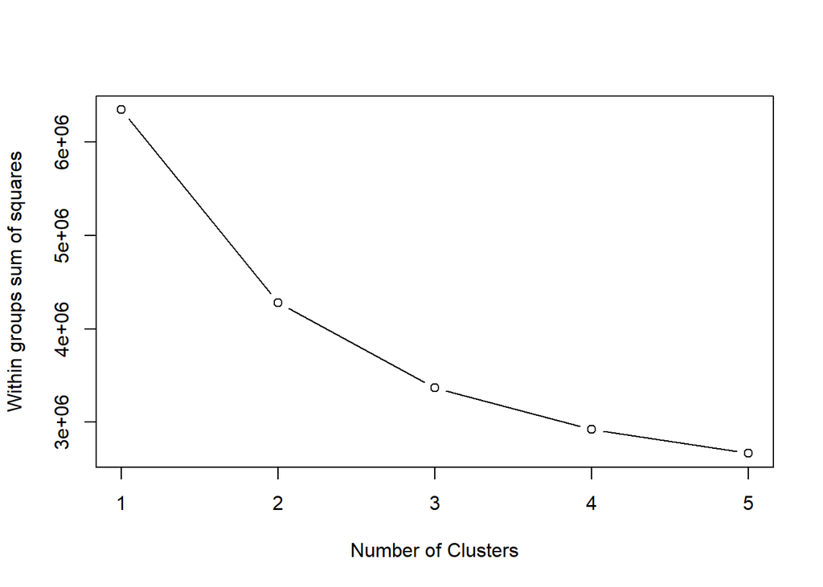

```r
# Quickplot of total within sum of squares vs. number of clusters
plot(1:scree_k, scree_wss, type = "b",
     xlab = "Number of Clusters",
     ylab = "Within groups sum of squares")
```

```r
# clean up environment
rm(i, scree_selection, scree_k, scree_ns, scree_wss, km_out)
```

```r
data_cluster_nogk <- data_cluster %>%
  select(-gk_diving, -gk_handling, -gk_kicking, -gk_positioning, -gk_reflexes)

tail(data_cluster_nogk)
```

```
##           V1 overall_rating potential crossing finishing heading_accuracy
## 183973 39902       2.045121 1.7504813 1.676887 1.4748336       0.10516022
## 183974 39902       2.045121 1.7504813 1.676887 1.4223090       0.10516022
## 183975 39902       1.335009 0.9920173 1.096913 1.3697845      -0.25872082
## 183976 39902       1.192987 0.9920173 1.096913 1.1071616      -0.25872082
## 183977 39902       1.335009 1.1437101 1.096913 0.7394895      -0.01613346
## 183978 39902       1.619054 1.1437101 1.096913 0.9495878      -0.01613346
##        short_passing  volleys dribbling    curve free_kick_accuracy
## 183973      1.731028 1.508032  1.399002 1.809526          1.6049493
## 183974      1.871932 1.508032  1.399002 1.809526          1.6049493
## 183975      1.519672 1.508032  1.455356 1.809526          1.3806303
## 183976      1.519672 1.508032  1.455356 1.809526          1.3806303
## 183977      1.660576 1.508032  1.568066 1.809526          1.3245506
## 183978      1.801480 1.508032  1.568066 1.809526          0.2029554
##        long_passing ball_control acceleration sprint_speed   agility
```

[output cut: 27 more lines]

### Second try scree and elbow plot

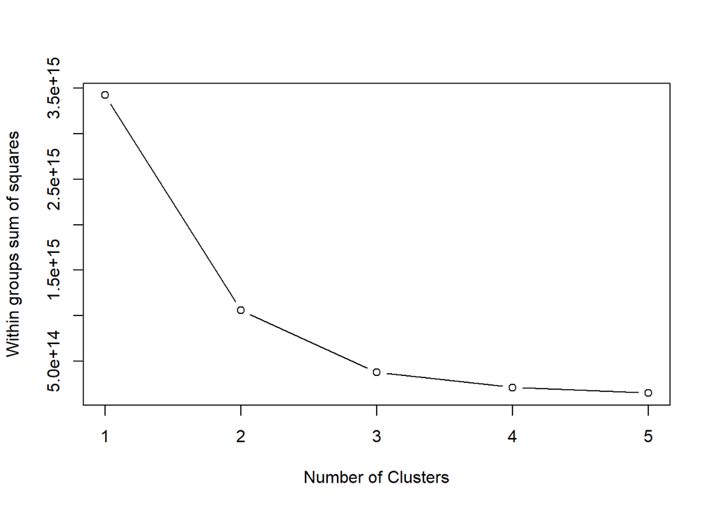

```r
scree2_selection <- data_cluster_nogk

# scree parameters
scree2_wss <- 0                 # initialize total within sum of squares error
scree2_k   <- 5                 # number of clusters to cycle
scree2_ns <- 10                 # number of random starts to cycle

# For 1 to 15 cluster centers
for (i in 1:scree2_k) {
  km_out2 <- kmeans(scree2_selection, centers = i, nstart = scree2_ns)
  # Save total within sum of squares to wss variable
  scree2_wss[i] <- km_out2$tot.withinss
}

# Quickplot of total within sum of squares vs. number of clusters
plot(1:scree2_k, scree2_wss, type = "b",
     xlab = "Number of Clusters",
     ylab = "Within groups sum of squares")
```

```r
# clean up environment
rm(i, scree2_selection, scree2_k, scree2_ns, scree2_wss, km_out2)
```

```r
# make relevant selection
data_cluster_elite <- temp_df %>%
  filter(overall_rating > 80) %>%
    select(player_api_id, overall_rating, potential, crossing, finishing, heading_accuracy, short_passing, volleys, dribbling, curve, free_kick_accuracy, long_passing, ball_control, acceleration, sprint_speed, agility, reactions, balance, shot_power, jumping, stamina, strength, long_shots, aggression, interceptions, positioning, vision, penalties, marking, standing_tackle, sliding_tackle) %>%
  scale() %>%
  data.frame()

# check NA %
((nrow(data_cluster_elite) - sum(complete.cases(data_cluster_elite))) / nrow(data_cluster_elite)) * 100
```

```
## [1] 0.9919323
```

Less then 1% of the records contains NA’s, let drop them in our quick and dirty approach.

```r
# drop incomplete records
data_cluster_elite <- data_cluster_elite %>%
  drop_na()
```

### Third try scree and elbow plot

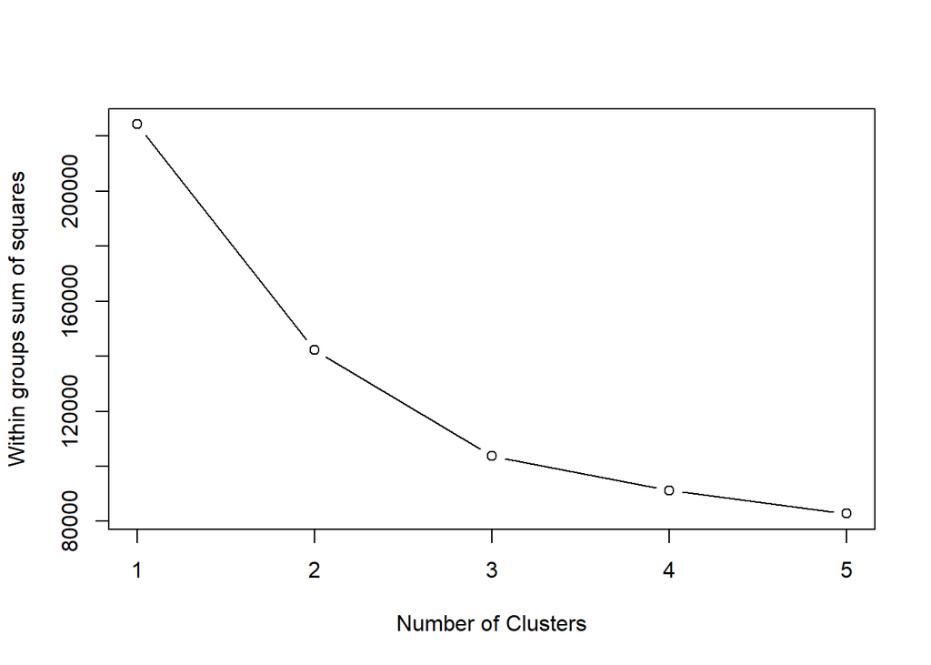

```r
scree3_selection <- data_cluster_elite[, -1]

# scree parameters
scree3_wss <- 0                 # initialize total within sum of squares error
scree3_k   <- 5                 # number of clusters to cycle
scree3_ns <- 10                 # number of random starts to cycle

# For 1 to 15 cluster centers
for (i in 1:scree3_k) {
  km_out3 <- kmeans(scree3_selection, centers = i, nstart = scree3_ns)
  # Save total within sum of squares to wss variable
  scree3_wss[i] <- km_out3$tot.withinss
}

# Quickplot of total within sum of squares vs. number of clusters
plot(1:scree3_k, scree3_wss, type = "b",
     xlab = "Number of Clusters",
     ylab = "Within groups sum of squares")
```

```r
# clean up environment
rm(i, scree3_selection, scree3_k, scree3_ns, scree3_wss, km_out3)
```

Just slightly better, but our elbow has been moved to the 3rd cluster. A little bit more differentation luckily. Another step to take would be to apply Principal Component Analysis over the variables, but due to time constraints we will skip that for now.

### Run clustering algorithm

```r
# set random seed for reproducibility
set.seed(1337)

# run k-means with 3 centers and 20 starts
k_output <- kmeans(data_cluster_elite[,-1], 3, nstart = 20)
```

### Merge clusters to data

```r
data_cluster_elite$cluster <- k_output$cluster
```

### Calculate cluster means

```r
# calculate cluster means as seperate columns and bind them together
clusters <-
  cbind(
data_cluster_elite[,-1] %>%
  subset(cluster == 1) %>%
  colMeans(),
data_cluster_elite[,-1] %>%
  subset(cluster == 2) %>%
  colMeans(),
data_cluster_elite[,-1] %>%
  subset(cluster == 3) %>%
  colMeans()
)

# set cluster number as columnnames
colnames(clusters) = clusters["cluster",]
```

### Plot cluster heatmap

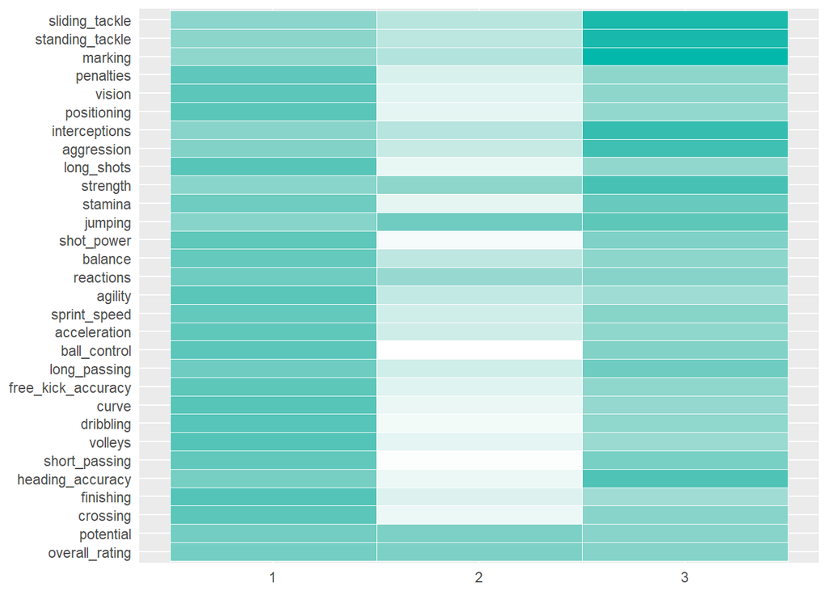

```r
# remove row names cluster and melt data
plotdata_h <-clusters[-which(rownames(clusters) %in% c("cluster")), ] %>%
  melt()

# remove columns to standardised names
colnames(plotdata_h) <- c("Var1", "Var2", "value")

# plot heatmap
ggplot(plotdata_h, aes(Var2, Var1)) + geom_tile(aes(fill = value), colour = "white") + scale_fill_gradient(low = "white", high = "#01B8AA") + theme(legend.position="none", axis.line=element_blank(), axis.ticks=element_blank(), axis.title.x=element_blank(), axis.title.y=element_blank())
```

### Business application

Let players train in different groups to groom different types of development.

```r
# clean up environment
rm(data_cluster, data_cluster_nogk, data_cluster_elite, clusters, k_output)
```

# Extra Feature 3: Prediction of preferred shooting foot

### Configuring training settings

First let us configure the training settings using the trainControl function from the caret package. By saving the settings to an object and having the random seed set at a constant (1337, set before clustering) we can easily reproduce the configuration when training other models.

```r
cfg_ctrl <- trainControl(
  method = "cv",
  number = 5,
  summaryFunction = twoClassSummary,
  classProbs = TRUE,
  verboseIter = TRUE
)
```

### Subsetting data

Now we will create a subset with only the target variable (left or right footedness) and the features predicting it (attributes).

```r
data_cp <- temp_df %>%
  select(preferred_foot, overall_rating, potential, crossing, finishing, heading_accuracy, short_passing, volleys, dribbling, curve, free_kick_accuracy, long_passing, ball_control, acceleration, sprint_speed, agility, reactions, balance, shot_power, jumping, stamina, strength, long_shots, aggression, interceptions, positioning, vision, penalties, marking, standing_tackle, sliding_tackle, gk_diving, gk_handling, gk_kicking, gk_positioning, gk_reflexes)
```

Again, let’s check what percentages of the records in incomplete.

```r
# check NA %
((nrow(data_cp) - sum(complete.cases(data_cp))) / nrow(data_cp)) * 100
```

```
## [1] 1.474633
```

Just 1.47%, because we are working quick and dirty for our first exploration, we are just going to drop these records for now.

```r
data_cp <- data_cp %>%
  drop_na()
```

### Time to train our models

Here we have three instances of model training, all with our same train (and test) configuration settings for model evaluation. This will allow us to make nice comparisions.

```r
# train general linear model
model_glm <- train(preferred_foot ~ .,
                   data = data_cp,
                   method = "glm",
                   trControl = cfg_ctrl)
# train with standard classification tree
model_rpart <- train(preferred_foot ~ .,
                   data = data_cp,
                   method = "rpart",
                   trControl = cfg_ctrl)
# train with general linear mmodel net with lasso and regression (tuned) to possibly prevent overfitting
model_glmnet <- train(preferred_foot ~ .,
                   data = data_cp,
                   tuneGrid = expand.grid(alpha = 0:1, lambda = seq(0.0001, 1, length = 20 )),
                   method = "glmnet",
                   trControl = cfg_ctrl)
# use random forest to prevent overfitting
# model_rf <- train(
                    #preferred_foot ~ .,
                    #data = data_cp,
                    #method = "ranger",
                    #trControl = cfg_ctrl)
```

#### Compare model outputs

```r
# create list of model outcomes
model_resamples <- list(glm = model_glm, ctree = model_rpart, glmnet = model_glmnet) %>%
  resamples()

# check out overview of model summaries
model_resamples %>%
  summary()
```

```
##
## Call:
## summary.resamples(object = .)
##
## Models: glm, ctree, glmnet
## Number of resamples: 5
##
## ROC
##             Min.   1st Qu.    Median      Mean   3rd Qu.      Max. NA's
## glm    0.6766999 0.6780204 0.6805215 0.6811217 0.6827798 0.6875868    0
## ctree  0.6156910 0.6181986 0.6187249 0.6203635 0.6226644 0.6265385    0
## glmnet 0.6780381 0.6786713 0.6808546 0.6812174 0.6824283 0.6860946    0
##
## Sens
##              Min.    1st Qu.     Median       Mean    3rd Qu.       Max.
## glm    0.08158429 0.08541126 0.08767773 0.08706441 0.08993455 0.09071421
## ctree  0.05810674 0.06793049 0.07560370 0.08203196 0.10291131 0.10560758
## glmnet 0.08068156 0.08101094 0.08192282 0.08413065 0.08711352 0.08992440
##        NA's
## glm       0
## ctree     0
## glmnet    0
##
## Spec
##             Min.   1st Qu.    Median      Mean   3rd Qu.      Max. NA's
## glm    0.9819649 0.9826220 0.9837532 0.9834177 0.9840459 0.9847024    0
## ctree  0.9751369 0.9789347 0.9871491 0.9837827 0.9887189 0.9889741    0
## glmnet 0.9832062 0.9833887 0.9844109 0.9841552 0.9848120 0.9849580    0
```

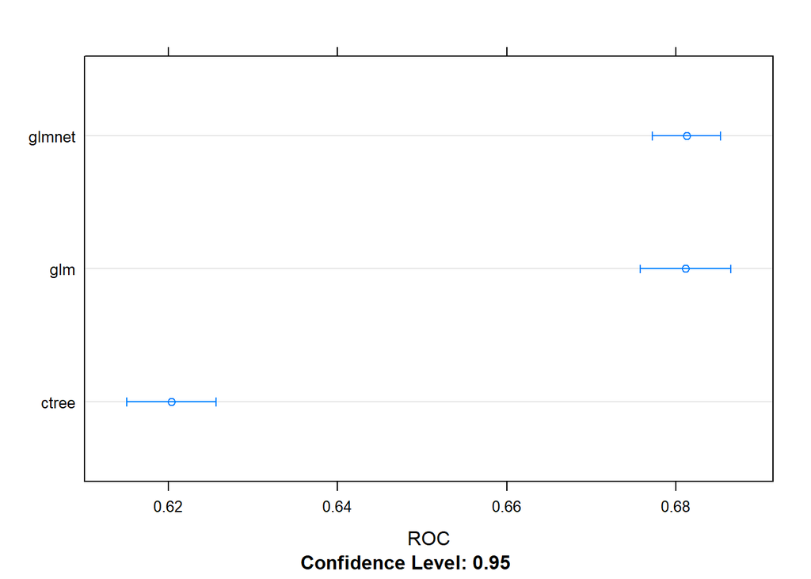

```r
# compare ROC means and spreads
model_resamples %>%
  dotplot(metric = "ROC")
```

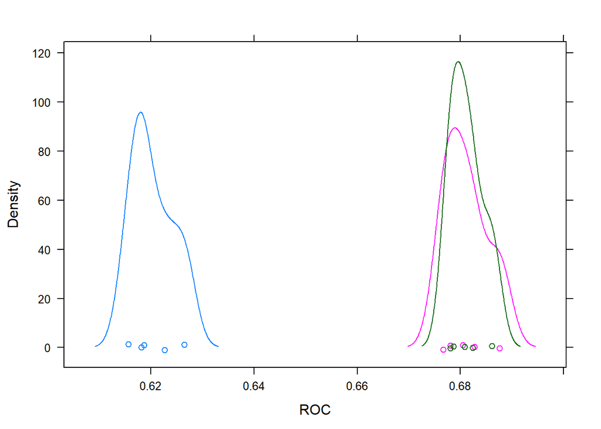

```r
# Check for for outliers
model_resamples %>%
  densityplot(metric = "ROC")
```

Here we can see that the tuned glmnet model has the highest ROC by a noselength. Let’s quickly look at the details.

```r
# best parameters used
model_glmnet$bestTune
```

```
##    alpha lambda
## 21     1  1e-04
```

### Model application

Now let’s apply the model to some of our data to see it in action.

```r
data_cp %>%
  mutate(predicted_foot = predict(model_glm, data_cp)) %>% # applying our model object to current dataset
  mutate(prediction_succes = predicted_foot == preferred_foot) %>%
  select(preferred_foot, predicted_foot, prediction_succes) %>%
  tail(20)
```

```
##        preferred_foot predicted_foot prediction_succes
## 181246           left          right             FALSE
## 181247           left          right             FALSE
## 181248          right          right              TRUE
## 181249          right          right              TRUE
## 181250          right          right              TRUE
## 181251          right          right              TRUE
## 181252          right          right              TRUE
## 181253          right          right              TRUE
## 181254          right          right              TRUE
## 181255          right          right              TRUE
## 181256          right          right              TRUE
## 181257          right          right              TRUE
## 181258          right          right              TRUE
## 181259          right          right              TRUE
## 181260          right          right              TRUE
## 181261          right          right              TRUE
## 181262          right          right              TRUE
## 181263          right          right              TRUE
## 181264          right          right              TRUE
## 181265          right          right              TRUE
```

# Output

To conclude we will store our tables as CSV’s so we can easily load them with PowerBI.

```r
write_csv(data_all[[1]], "./data/countries.csv")
write_csv(data_all[[2]], "./data/competitions.csv")
write_csv(data_all[[3]], "./data/games.csv")
write_csv(data_all[[4]], "./data/players.csv")
write_csv(data_all[[5]], "./data/attributes.csv")
write_csv(data_all[[6]], "./data/teams.csv")
write_csv(data_all[[7]], "./data/tactics.csv")
write_csv(league_tables, "./data/league_tables.csv")
write_csv(plotdata_h, "./data/plotdata_heatmap.csv")
```